# Environmental and Genomic Data Analysis

G. Santoro

Estimating daily PM10 levels with 1 km x 1 km (cell) resolution in a 200 Km x 200 Km (40000 cells) area southeast of Great Britain.

Set up and libraries load

```r
setwd(dirname(rstudioapi::getActiveDocumentContext()$path))

library(rpart); library(corrplot); library(caret); library(earth); library(broom); library(plotmo); library(ranger); library(randomForest); library(xgboost); library(neuralnet); library(keras)
```

Load dataset as a dataframe

```r
datapm<-readRDS("dataPM10LONDON.RDS")

str(datapm)
```

```
'data.frame':   56670 obs. of  55 variables:
 $ day                   : Date, format: "2018-09-22" "2018-09-23" "2018-09-24" "2018-09-25" ...
 $ code.source           : chr  "BMLD.AURN" "BMLD.AURN" "BMLD.AURN" "BMLD.AURN" ...
 $ osgrid.id             : chr  "SP0587" "SP0587" "SP0587" "SP0587" ...
 $ logpm10               : num  2.38 2.31 2.77 2.94 2.83 ...
 $ pm10                  : num  10.8 10 15.9 19 16.9 ...
 $ we                    : num  1 1 0 0 0 0 0 1 1 0 ...
 $ Jan                   : num  0 0 0 0 0 0 0 0 0 0 ...
 $ Feb                   : num  0 0 0 0 0 0 0 0 0 0 ...
 $ Mar                   : num  0 0 0 0 0 0 0 0 0 0 ...
 $ Apr                   : num  0 0 0 0 0 0 0 0 0 0 ...
 $ May                   : num  0 0 0 0 0 0 0 0 0 0 ...
 $ Jun                   : num  0 0 0 0 0 0 0 0 0 0 ...
 $ Jul                   : num  0 0 0 0 0 0 0 0 0 0 ...
 $ Aug                   : num  0 0 0 0 0 0 0 0 0 0 ...
```

[output cut: 41 more lines]

Dataset has a historical series structure: every record is a daily measure of a monitor, with a total 56670 observations of 55 variables.

```r
monitors<-unique(datapm$code.source)  # code.source code of the specific monitor
(nmonitors<-length(monitors))  # monitor amount
```

```
[1] 179
```

```r
osgrid<-unique(datapm$osgrid.id)   # cell code
(nosgrid<-length(osgrid)) # cell amount
```

```
[1] 160
```

```r
#summary(datapm)
```

VARIABLES INCLUDED IN THE DATASET

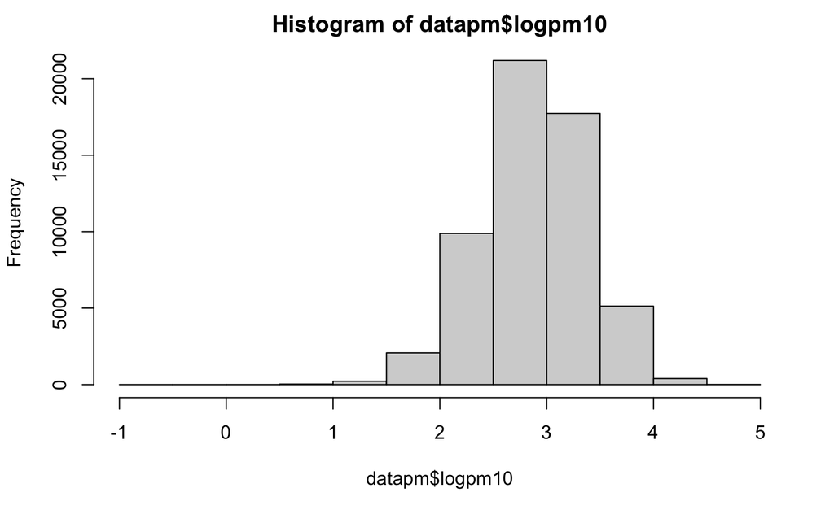

```r
# # RESPONSE
# summary(datapm$logpm10)
hist(datapm$logpm10)
```

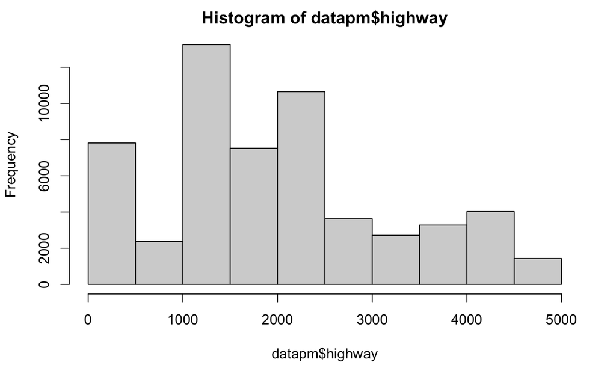

```r
#
# # PREDICTORS
#
# ### TIME
# table(datapm$we)  # weekend or not. 2 : 7
#
# table(datapm$Jan)  # 1 : 12
# table(datapm$Feb)
# table(datapm$Mar)
# table(datapm$Apr)
# table(datapm$May)
# table(datapm$Jun)
# table(datapm$Jul)
# table(datapm$Aug)
# table(datapm$Sep)
# table(datapm$Oct)
# table(datapm$Nov)
#
# ### ROADS LENGTH
# summary(datapm$highway)
hist(datapm$highway)
```

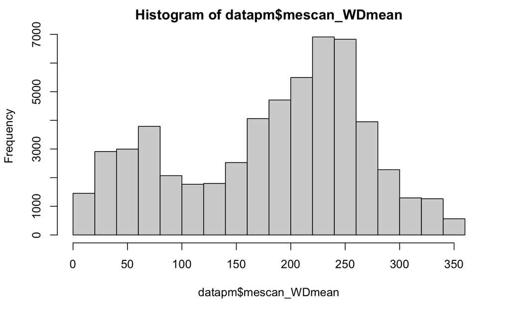

```r
#
# summary(datapm$secondary)
# hist(datapm$secondary)
#
# summary(datapm$local)
# hist(datapm$local)
#
# # DISTANCES FROM AIRPORTS AND SEASHORE
# summary(datapm$sea.invd)
# hist(datapm$sea.invd)
#
# summary(datapm$airp.invd)
# hist(datapm$airp.invd)
#
#
# # POPULATION
# summary(datapm$OA.popwei.1km)  # people in 1 km^2?
# hist(datapm$OA.popwei.1km)
#
# # ELEVATION
# summary(datapm$elev.1km)
# hist(datapm$elev.1km)
#
# # NIGHT LIGHTS
# summary(datapm$night.1km)
# hist(datapm$night.1km)
#
#
# # IMPERVIOUS SOURFACES
# summary(datapm$ImpS)
# hist(datapm$ImpS)
#
#
# # NDVI
# summary(datapm$ndvi)
# hist(datapm$ndvi)
#
#
# # LAND USE
# summary(datapm$cl1)
# hist(datapm$cl1)
#
# summary(datapm$cl2)
# hist(datapm$cl2)
#
# summary(datapm$cl3)
# hist(datapm$cl3)
#
# summary(datapm$cl4)
# hist(datapm$cl4)
#
# summary(datapm$cl5)
# hist(datapm$cl5)
#
# summary(datapm$cl6)
# hist(datapm$cl6)
#
# summary(datapm$cl7)
# hist(datapm$cl7)
#
# # BOUNDARY LAYER HEIGHT
# summary(datapm$era5_PBL0h)
# hist(datapm$era5_PBL0h)
#
# summary(datapm$era5_PBL12h)
# hist(datapm$era5_PBL12h)
#
# # SEA LEVEL PRESSURE
# summary(datapm$era5_SeaPrmean)
# hist(datapm$era5_SeaPrmean)
#
# # MEAN TEMPERATURE
# summary(datapm$eraland_Tmean)
# hist(datapm$eraland_Tmean)
#
# # PRECIPITATIONS
# summary(datapm$eraland_Precmean)
# hist(datapm$eraland_Precmean)
#
# # RELATIVE HUMIDITY
# summary(datapm$mescan_RHmean)
# hist(datapm$mescan_RHmean)
#
# # WIND SPEED
# summary(datapm$mescan_WSmean)
# hist(datapm$mescan_WSmean)
#
# # WIND DIRECTION
# summary(datapm$mescan_WDmean)
hist(datapm$mescan_WDmean)
```

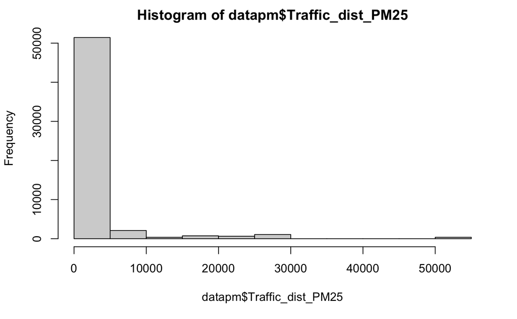

```r
#
# # CHEMICAL TRANSPORT MODEL EMEP4UK
#
# # PM25
# summary(datapm$logEMEPUK_PM25)
# hist(datapm$logEMEPUK_PM25)
#
# # PM10
# summary(datapm$logEMEPUK_PM10)
# hist(datapm$logEMEPUK_PM10)
#
# # DUST
# summary(datapm$logEMEPUK_DUST)
# hist(datapm$logEMEPUK_DUST)
#
# # SEA SALT
# summary(datapm$logEMEPUK_SSALT)
# hist(datapm$logEMEPUK_SSALT)
#
# # aerosol optical depth (AOD)
# summary(datapm$best_AOD047_pred_measu)
# hist(datapm$best_AOD047_pred_measu)
#
# summary(datapm$best_AOD055_pred_measu)
# hist(datapm$best_AOD055_pred_measu)
#
# # Spatially-Lagged and Nearest Monitor PM2.5 Variables
#
# # TRAFFIC
# summary(datapm$idw1logpm25traf)
# hist(datapm$idw1logpm25traf)
#
# summary(datapm$idw2logpm25traf)
# hist(datapm$idw2logpm25traf)
#
# summary(datapm$Traffic_dist_PM25)
hist(datapm$Traffic_dist_PM25)
```

```r
#
# # BACKGROUND
# summary(datapm$idw1logpm25nontraf)
# hist(datapm$idw1logpm25nontraf)
#
# summary(datapm$idw2logpm25nontraf)
# hist(datapm$idw2logpm25nontraf)
#
# summary(datapm$nonTraffic_dist_PM25)
# hist(datapm$nonTraffic_dist_PM25)
```

Here some of the variable of the dataset are plotted to see some distributions of predictors. logpm10: outcome, simmetrical and not far from a normal distr. mescan_WDmean: mean value of the wind, maybe binormal since two preferable way of the wind over the surface? highway: inverse of the distance from highways Traffic_dist_PM25: minimum distance from a monitor

# EXPLORE CORRELATION AMONG PREDICTORS

```r
# DEFINE VARIABLES
predictors.n <- c(
  ##### PREDICTORS #####
  ### TIME
  "we","Jan","Feb", "Mar", "Apr","May", "Jun", "Jul", "Aug", "Sep","Oct", "Nov",
  ### ROADS LENGTH
  "highway","secondary", "local",
  ### SEA, AIRPORTS INVERSE DISTANCE
  "sea.invd","airp.invd",
  ### POPULATION
  "OA.popwei.1km",
  ### NIGHT LIGHTS, ISA, ELEVATION, NDVI
  "night.1km","ImpS","elev.1km","ndvi",
  ### LAND USE (%)
  "cl1" , "cl2" , "cl3" , "cl4" ,
  "cl5" , "cl6" , "cl7" ,
  ### METEO
  "era5_PBL0h","era5_PBL12h",
  "era5_SeaPrmean",
  "eraland_Tmean","eraland_Precmean",
  "mescan_RHmean","mescan_WDmean","mescan_WSmean",
  ### AOD
  "best_AOD047_pred_measu", "best_AOD055_pred_measu",
  ### EMEP4UK
  "logEMEPUK_PM25", "logEMEPUK_PM10",
  "logEMEPUK_DUST","logEMEPUK_SSALT" ,
  ## MONITOR DISTANCE
  "Traffic_dist_PM25","nonTraffic_dist_PM25",
  #IDW TRAFFIC AND NONTRAFFIC
  "idw2logpm25traf","idw1logpm25traf",
  "idw2logpm25nontraf", "idw1logpm25nontraf"
)

predictors<-datapm[,predictors.n]

feature_variance<-nearZeroVar(predictors, saveMetrics=TRUE)

corpredictor<-cor(predictors, method="pearson")
```

High correlation can lead to collinearity issues, negatively impacting predictive model performance. Define the set of predictors and calculate the Pearson correlation matrix among them.

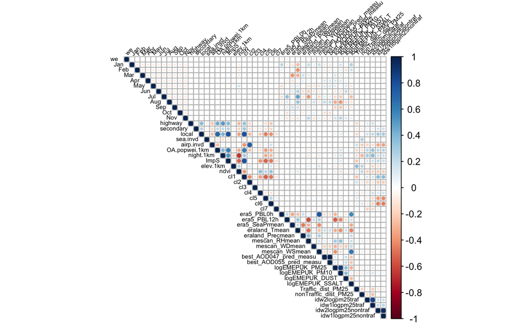

```r
layout(1)
par(mex=1)
corrplot(corpredictor, type = "upper",
  tl.col = "black", tl.srt = 45,tl.cex=0.5)
```

In caret (Classification and Regression Training) package there’s findCorrelation() to identify predictors with high correlation.

```r
high_corel<-findCorrelation(corpredictor, cutoff=0.9)

(highcor<-names(predictors)[high_corel])
```

```
[1] "idw2logpm25nontraf"     "best_AOD047_pred_measu"
```

There’re 2 variables with correlation greater than 0.9: idw2logpm25nontraf e best_AOD047_pred_measu, with respect to idw1logpm25nontraf and best_AOD055_pred_measu.

```r
corpredictor[,high_corel]
```

```
                       idw2logpm25nontraf best_AOD047_pred_measu
we                           0.0021180697          -0.0556583603
Jan                          0.0056575302          -0.0961946447
Feb                         -0.0013143798          -0.0833343806
Mar                          0.0015094593           0.0277382083
Apr                          0.0046578272           0.1350598862
May                          0.0140706443           0.1398255898
Jun                          0.0075613961           0.0116404775
Jul                         -0.0084478849           0.1038748055
Aug                         -0.0015434166           0.2176891802
Sep                         -0.0061437747          -0.0339696636
Oct                         -0.0080442083          -0.1461840828
Nov                          0.0008311996          -0.1009592170
highway                      0.0455091451          -0.0059360125
secondary                    0.1523143418          -0.0011847934
local                        0.2992056498          -0.0112877575
sea.invd                     0.0748254146           0.0085055334
airp.invd                   -0.3259903244           0.0099538396
OA.popwei.1km                0.2357208372          -0.0095098113
night.1km                    0.1812780185           0.0056519168
ImpS                         0.2228583011          -0.0102262827
elev.1km                    -0.1445438033          -0.0201946861
ndvi                        -0.2250109129           0.0286892888
cl1                          0.3617993104          -0.0134850155
cl2                         -0.2282233820           0.0060933852
cl3                          0.1201749626          -0.0006904429
cl4                          0.1322766802           0.0082544107
cl5                         -0.3723918899           0.0046668699
cl6                         -0.4468376244          -0.0011756029
cl7                          0.0907106808           0.0036473731
era5_PBL0h                  -0.0026031973          -0.1473909404
era5_PBL12h                 -0.0135831213          -0.0748626730
era5_SeaPrmean               0.0010109644          -0.0405632929
eraland_Tmean                0.0073103985           0.1956125977
eraland_Precmean             0.0059333773           0.0808444999
mescan_RHmean               -0.0030395206           0.0943726371
mescan_WDmean               -0.0033561228          -0.2081515578
mescan_WSmean               -0.0196875719          -0.1411451219
best_AOD047_pred_measu       0.0099723528           1.0000000000
best_AOD055_pred_measu       0.0094952676           0.9926571106
logEMEPUK_PM25               0.0323024065           0.1181724013
logEMEPUK_PM10               0.0648136724           0.0358775813
logEMEPUK_DUST               0.0264693676           0.1902199879
logEMEPUK_SSALT              0.0092102002          -0.2444914979
Traffic_dist_PM25           -0.1057344517          -0.0043472850
nonTraffic_dist_PM25         0.0368253596          -0.0032122757
idw2logpm25traf              0.1635763088           0.0035602056
idw1logpm25traf              0.2120365113           0.0068654655
idw2logpm25nontraf           1.0000000000           0.0099723528
idw1logpm25nontraf           0.9401645434           0.0080971380
```

With findLinearCombos() check if there’s linear combination within variables:

```r
(lincomb<-findLinearCombos(predictors))
```

```
$linearCombos
list()

$remove
NULL
```

In this case there is no linear correlation.

Delete idw2logpm25nontraf e best_AOD047_pred_measu since they aren’t adding info, since very correlated with 2 other variables.

```r
datapm$idw2logpm25nontraf<-NULL
datapm$best_AOD047_pred_measu<-NULL
```

Data are clustered by monitors, so assess accuracy of the model by dividing the monitors into two groups: training and test sets. The variable “split” contains the indicator for the 10 random groups into which the 179 monitoring stations have been divided.

# TRAIN-TEST dataset

```r
table(datapm$split)  # devide dataset into this sections
```

```
   1    2    3    4    5    6    7    8    9   10
4475 7650 5821 6005 5572 5838 5321 4990 5381 5617
```

```r
#table(datapm$code.source, as.factor(datapm$split)) # which monitor in which section
```

Assing 3 groups to test and 7 to train:

```r
set.seed(23)

test1<-datapm[datapm$split%in%sample(1:10,3),]

train1<-datapm[!datapm$split%in%sample(1:10,7),]
```

Alternatively, without considering clusterizzation of the monitors:

```r
set.seed(23)
random.test<-runif(nrow(datapm))
test2<-datapm[random.test>=0.7,]
train2<-datapm[random.test<0.7,]
```

Put these dataframes into a list:

```r
data.test.train<-list(train1,test1, train2,test2)
```

# REGRESSION

Multivariable linear regression model. Let’s consider the training data frame train, which is the first element of the data.test.train list. Define the train.features dataframe containing predictors and the train.outcome vector containing the outcome (logpm10).

```r
train<-data.test.train[[1]]

names(train)
```

```
 [1] "day"                    "code.source"            "osgrid.id"              "logpm10"                "pm10"
 [6] "we"                     "Jan"                    "Feb"                    "Mar"                    "Apr"
[11] "May"                    "Jun"                    "Jul"                    "Aug"                    "Sep"
[16] "Oct"                    "Nov"                    "highway"                "secondary"              "local"
[21] "sea.invd"               "airp.invd"              "OA.popwei.1km"          "night.1km"              "ImpS"
[26] "elev.1km"               "ndvi"                   "cl1"                    "cl2"                    "cl3"
[31] "cl4"                    "cl5"                    "cl6"                    "cl7"                    "era5_PBL0h"
[36] "era5_PBL12h"            "era5_SeaPrmean"         "eraland_Tmean"          "eraland_Precmean"       "mescan_RHmean"
[41] "mescan_WDmean"          "mescan_WSmean"          "best_AOD055_pred_measu" "logEMEPUK_PM25"         "logEMEPUK_PM10"
[46] "logEMEPUK_DUST"         "logEMEPUK_SSALT"        "Traffic_dist_PM25"      "nonTraffic_dist_PM25"   "idw2logpm25traf"
[51] "idw1logpm25traf"        "idw1logpm25nontraf"     "split"
```

```r
train.features<-train[,c(6:52)]  # predictors

train.outcome<-train[,4]   #Outcome = logpm10
```

# MAX-MIN NORMALIZATION

To compare the obtained coefficients and analyze the differences with subsequent models, let’s transform the predictive variables (features) into variables with values ranging from 0 to 1.

```r
normalize <- function(x) {
  return ((x - min(x)) / (max(x) - min(x)))
}

train.features.s<-as.data.frame(lapply(train.features, normalize))
```

# MULTIPLE REGRESSION

Predictor selection: non-informative predictors can lead to model overfitting. Implemented automatic predictor selection in a linear regression model,forward selection using the train() function. Every iteration the model considers one more variable.

```r
datalm<-train.features.s

train_logy<-train.outcome

# Control parameters
step_control<-trainControl(method="cv",
                           number = 5,
                           returnResamp = "final")

set.seed(23)

step_fit<-train(datalm,train_logy, method ="leapForward",
                tuneGrid = data.frame(nvmax=1:48),
                trControl = step_control,
                trace = TRUE)

step_fit$results
```

|  | nvmax | RMSE | Rsquared | MAE | RMSESD | RsquaredSD | MAESD |
| --- | --- | --- | --- | --- | --- | --- | --- |
| 1 | 1 | 0.3989853 | 0.2847321 | 0.3119495 | 0.007713760 | 0.01309714 | 0.003404039 |
| 2 | 2 | 0.3757096 | 0.3656700 | 0.2922403 | 0.007765744 | 0.01596584 | 0.003869550 |
| 3 | 3 | 0.3634338 | 0.4063966 | 0.2822148 | 0.008129159 | 0.01950530 | 0.004541591 |
| 4 | 4 | 0.3553909 | 0.4322989 | 0.2752540 | 0.007633963 | 0.01524697 | 0.004005044 |
| 5 | 5 | 0.3487322 | 0.4533453 | 0.2695621 | 0.006645840 | 0.01200067 | 0.003004826 |
| 6 | 6 | 0.3463795 | 0.4607115 | 0.2682646 | 0.007006387 | 0.01359930 | 0.003380605 |
| 7 | 7 | 0.3439943 | 0.4681114 | 0.2671608 | 0.006942857 | 0.01429146 | 0.003474331 |
| 8 | 8 | 0.3419774 | 0.4743673 | 0.2652045 | 0.006995023 | 0.01482673 | 0.003123121 |
| 9 | 9 | 0.3398815 | 0.4808054 | 0.2629932 | 0.007275399 | 0.01501528 | 0.003463048 |
| 10 | 10 | 0.3373939 | 0.4883993 | 0.2603427 | 0.007513968 | 0.01580565 | 0.003532595 |

[output cut: 38 more lines]

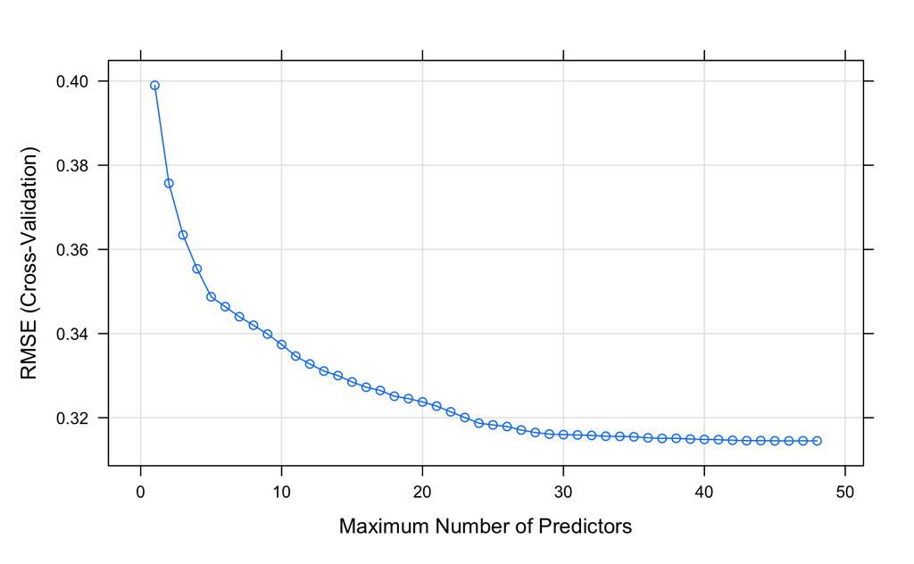

```r
plot(step_fit)
```

```r
(nfit<-as.integer(step_fit$bestTune))  # numero che ottimizza il RMSE, dopo i 39, in
```

```
[1] 45
```

```r
# questo caso il modello predice peggio perchè si introduce rumore
```

The number that optimizes the RMSE is 45. In this case the model predicts worse because noise is introduced with more variables included.

```r
step_coef<-tidy(coef(step_fit$finalModel,nfit))
step_coef<-step_coef[-1,]

(lm_formula<-as.formula(paste("y~",paste(step_coef$names[-1],collapse="+"),sep="")))
```

```
y ~ Jan + Feb + Mar + Apr + May + Jun + Jul + Aug + Sep + Oct +
    Nov + highway + secondary + local + sea.invd + airp.invd +
    OA.popwei.1km + night.1km + ImpS + elev.1km + ndvi + cl1 +
    cl2 + cl3 + cl4 + cl5 + cl6 + cl7 + era5_PBL0h + era5_PBL12h +
    eraland_Tmean + eraland_Precmean + mescan_RHmean + mescan_WDmean +
    mescan_WSmean + best_AOD055_pred_measu + logEMEPUK_PM25 +
    logEMEPUK_PM10 + logEMEPUK_DUST + Traffic_dist_PM25 + nonTraffic_dist_PM25 +
    idw2logpm25traf + idw1logpm25traf + idw1logpm25nontraf
```

datalmy dataframe contains model predictors and outcome. Estimate model parameters with lm():

```r
datalmy<-datalm

datalmy$y<-train_logy

step_lm<-lm(lm_formula, datalmy)

summary(step_lm)
```

```
Call:
lm(formula = lm_formula, data = datalmy)

Residuals:
    Min      1Q  Median      3Q     Max
-3.1816 -0.1914  0.0073  0.1988  1.5845

Coefficients:
                       Estimate Std. Error t value Pr(>|t|)
(Intercept)             3.02776    0.05092  59.460  < 2e-16 ***
Jan                     0.05490    0.01170   4.692 2.72e-06 ***
Feb                     0.09469    0.01307   7.246 4.46e-13 ***
Mar                     0.21531    0.01264  17.035  < 2e-16 ***
Apr                     0.13215    0.01297  10.186  < 2e-16 ***
May                     0.18221    0.01547  11.775  < 2e-16 ***
Jun                     0.01306    0.01690   0.773 0.439707
Jul                     0.11029    0.02045   5.394 6.98e-08 ***
Aug                     0.10364    0.01862   5.565 2.67e-08 ***
Sep                     0.10354    0.01544   6.706 2.06e-11 ***
Oct                    -0.07853    0.01249  -6.288 3.29e-10 ***
Nov                     0.06809    0.01202   5.666 1.48e-08 ***
highway                 0.22461    0.01542  14.563  < 2e-16 ***
secondary              -0.07660    0.01238  -6.188 6.24e-10 ***
local                  -0.32336    0.03276  -9.872  < 2e-16 ***
sea.invd                0.30633    0.04052   7.560 4.22e-14 ***
airp.invd               0.13207    0.03990   3.310 0.000936 ***
OA.popwei.1km          -0.14037    0.02424  -5.792 7.08e-09 ***
night.1km               0.08083    0.01618   4.995 5.93e-07 ***
ImpS                    0.12502    0.03469   3.604 0.000314 ***
elev.1km                0.11678    0.02154   5.421 6.00e-08 ***
ndvi                    0.13103    0.03312   3.957 7.63e-05 ***
cl1                    -0.37578    0.04780  -7.862 4.00e-15 ***
cl2                    -1.17030    0.04361 -26.838  < 2e-16 ***
cl3                    -0.60615    0.08426  -7.194 6.57e-13 ***
cl4                    -0.31621    0.02301 -13.741  < 2e-16 ***
cl5                    -0.47828    0.02411 -19.836  < 2e-16 ***
cl6                    -0.55056    0.02908 -18.934  < 2e-16 ***
cl7                     0.10015    0.08319   1.204 0.228669
era5_PBL0h             -0.26226    0.02752  -9.531  < 2e-16 ***
era5_PBL12h            -0.08507    0.02195  -3.876 0.000107 ***
eraland_Tmean           0.18922    0.02835   6.674 2.57e-11 ***
eraland_Precmean       -0.61149    0.03104 -19.703  < 2e-16 ***
mescan_RHmean          -0.52380    0.02324 -22.537  < 2e-16 ***
mescan_WDmean          -0.30167    0.01150 -26.237  < 2e-16 ***
mescan_WSmean           0.07019    0.03612   1.943 0.052012 .
best_AOD055_pred_measu  0.17871    0.02563   6.973 3.21e-12 ***
logEMEPUK_PM25          0.94104    0.04304  21.862  < 2e-16 ***
logEMEPUK_PM10          0.79435    0.05191  15.304  < 2e-16 ***
logEMEPUK_DUST         -0.03931    0.02029  -1.937 0.052709 .
Traffic_dist_PM25      -0.40101    0.01534 -26.133  < 2e-16 ***
nonTraffic_dist_PM25    0.17088    0.02269   7.532 5.22e-14 ***
idw2logpm25traf         0.30148    0.03044   9.904  < 2e-16 ***
idw1logpm25traf        -0.05421    0.03458  -1.568 0.116940
idw1logpm25nontraf     -0.38249    0.02854 -13.403  < 2e-16 ***
---
Signif. codes:  0 ‘***’ 0.001 ‘**’ 0.01 ‘*’ 0.05 ‘.’ 0.1 ‘ ’ 1

Residual standard error: 0.3151 on 17398 degrees of freedom
Multiple R-squared:  0.5548,    Adjusted R-squared:  0.5537
F-statistic: 492.7 on 44 and 17398 DF,  p-value: < 2.2e-16
```

Let’s evaluate the model predictive capability on the train set using the postResample() function from caret package:

```r
pred_lm_train<-predict(step_lm,datalm)

postResample(pred=pred_lm_train, obs=train_logy)
```

```
     RMSE  Rsquared       MAE
0.3147378 0.5547962 0.2423492
```

The predictive capacity of the linear regression model (measured by R-squared) is 55.48%, with an RMSE of 0.314.

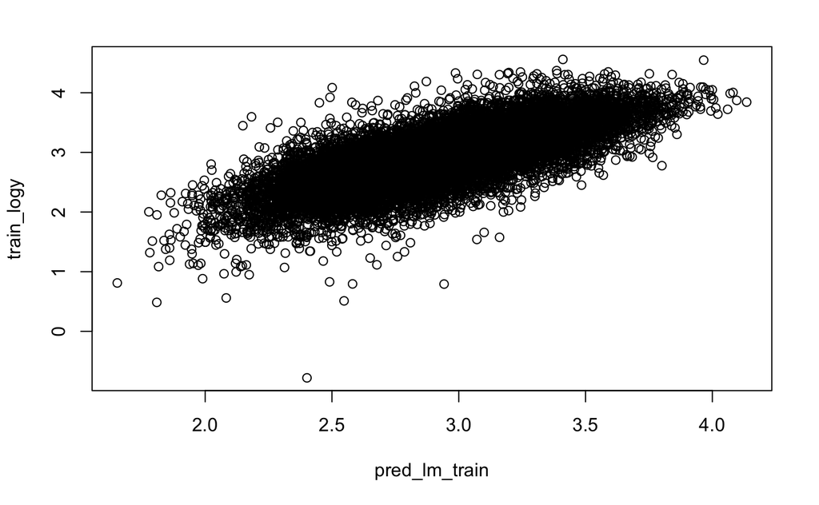

```r
plot(pred_lm_train, train_logy)
```

Manage test set similarly as done before to the train one.

```r
test<-data.test.train[[2]]

names(test)
```

```
 [1] "day"                    "code.source"            "osgrid.id"              "logpm10"                "pm10"
 [6] "we"                     "Jan"                    "Feb"                    "Mar"                    "Apr"
[11] "May"                    "Jun"                    "Jul"                    "Aug"                    "Sep"
[16] "Oct"                    "Nov"                    "highway"                "secondary"              "local"
[21] "sea.invd"               "airp.invd"              "OA.popwei.1km"          "night.1km"              "ImpS"
[26] "elev.1km"               "ndvi"                   "cl1"                    "cl2"                    "cl3"
[31] "cl4"                    "cl5"                    "cl6"                    "cl7"                    "era5_PBL0h"
[36] "era5_PBL12h"            "era5_SeaPrmean"         "eraland_Tmean"          "eraland_Precmean"       "mescan_RHmean"
[41] "mescan_WDmean"          "mescan_WSmean"          "best_AOD055_pred_measu" "logEMEPUK_PM25"         "logEMEPUK_PM10"
[46] "logEMEPUK_DUST"         "logEMEPUK_SSALT"        "Traffic_dist_PM25"      "nonTraffic_dist_PM25"   "idw2logpm25traf"
[51] "idw1logpm25traf"        "idw1logpm25nontraf"     "split"
```

```r
test.features<-test[,c(6:52)]

test.outcome<-test[,4]

test.features.s<-as.data.frame(lapply(test.features, normalize))
test.features.s$cl3[is.na(test.features.s$cl3)]<-0
test.features.s$cl7[is.na(test.features.s$cl7)]<-0 # for missing values

pred_lm_test<-predict(step_lm,test.features.s)

postResample(pred_lm_test, test.outcome)  # test predictive performance
```

```
     RMSE  Rsquared       MAE
0.3522913 0.4838807 0.2696755
```

As expected the model perfors better on the train set. Over the test set R^2 is 48.39%.

# MARS (Multivariate Adaptive Regression Splines): to evaluate the potential non-linear relationships of each predictor.

Parameterizing with lines that can change direction when they encounter an internal node within the exposure range. Use the concept of variable expansion creating new variables starting from the initial ones.

First without considering interaction terms (degree = 1).

```r
set.seed(23)

earth_fit<-earth(
  x = datalm,    # predictors dataset
  y = train.outcome,
  pmethod='cv',
  nfold = 5,
  degree = 1,  # with or without interactions
  minspan = -1  # one internal node
)
```

```r
summary(earth_fit) # earth fit contains the model
```

```
Call: earth(x=datalm, y=train.outcome, pmethod="cv", degree=1, nfold=5, minspan=-1)

                                   coefficients
(Intercept)                           2.7443574
we                                   -0.0559520
Mar                                   0.2256115
Apr                                   0.1606694
May                                   0.1827353
Aug                                  -0.0757558
Oct                                  -0.1085068
Nov                                   0.0808921
cl2                                  -1.6341265
cl5                                  -0.6916995
cl6                                  -0.2932674
cl7                                  -0.6316255
Traffic_dist_PM25                     0.3561176
h(0.3979-highway)                    -0.5861856
h(highway-0.3979)                     0.0320980
h(0.563473-local)                     0.7602961
h(local-0.563473)                    -0.8196865
h(0.0385533-airp.invd)                0.8351941
h(airp.invd-0.0385533)                0.6060429
h(0.276012-OA.popwei.1km)             0.5687956
h(OA.popwei.1km-0.276012)            -0.0428801
h(0.319117-night.1km)                 0.8914416
h(night.1km-0.319117)                -0.0972712
h(0.767073-ImpS)                     -0.5973555
h(ImpS-0.767073)                      2.1808195
h(0.160796-elev.1km)                  0.0465994
h(elev.1km-0.160796)                  0.1708016
h(0.634518-cl1)                       0.2052884
h(cl1-0.634518)                      -0.9966262
h(0.148075-era5_PBL0h)                1.2044445
h(era5_PBL0h-0.148075)               -0.0307825
h(0.381182-era5_PBL12h)               0.4761247
h(era5_PBL12h-0.381182)               0.1710922
h(0.571597-era5_SeaPrmean)           -0.0179102
h(era5_SeaPrmean-0.571597)           -0.2277499
h(0.514205-eraland_Tmean)             0.2334746
h(eraland_Tmean-0.514205)             0.6448221
```

[output cut: 14 more lines]

```
h(0.0559691-nonTraffic_dist_PM25)    -8.0932572
h(nonTraffic_dist_PM25-0.0559691)    -0.1146233
h(0.543275-idw2logpm25traf)           0.1654688
h(idw2logpm25traf-0.543275)           0.8589945
h(0.689495-idw1logpm25nontraf)        0.5020971
h(idw1logpm25nontraf-0.689495)       -0.0101933

Selected 57 of 57 terms, and 34 of 47 predictors (pmethod="cv")
Termination condition: RSq changed by less than 0.001 at 57 terms
Importance: logEMEPUK_PM25, mescan_RHmean, nonTraffic_dist_PM25, idw2logpm25traf, mescan_WDmean, era5_PBL0h, Oct, cl2, cl5, ...
Number of terms at each degree of interaction: 1 56 (additive model)
GRSq 0.6173889  RSq 0.6222869  mean.oof.RSq 0.6238889 (sd 0.0071)

pmethod="backward" would have selected:
    49 terms 34 preds,  GRSq 0.6178094  RSq 0.6220049  mean.oof.RSq 0.6198575
```

Three different indices to represent importance: - nsubsets indicates the number of “subsets” in which the variable is included. A subset refers to a model with a number of terms lower than that determined by the optimal model.

- generalized cross-validation is calculated by computing the difference of the GCV between models containing or not containing the variable in question. The value is normalized to the maximum value calculated for the considered variables, which is set equal to 100.
- rss is calculated through the difference in the sum of the squares of the residuals between models containing or not containing the variable in question. The value is normalized to the maximum value calculated for the considered variables, which is set equal to 100.

Showing variables predictive capabilities:

```r
evimp(earth_fit)
```

```
                       nsubsets   gcv    rss
logEMEPUK_PM25               56 100.0  100.0
mescan_RHmean                55  76.9   77.1
nonTraffic_dist_PM25         54  69.2   69.5
idw2logpm25traf              53  62.7   63.0
mescan_WDmean                52  58.1   58.5
era5_PBL0h                   51  53.3   53.7
Oct                          50  48.1   48.6
cl2                          49  46.2   46.7
cl5                          47  43.5   44.0
idw1logpm25nontraf           47  43.5   44.0
logEMEPUK_PM10               46  41.7   42.3
eraland_Tmean                45  40.0   40.6
eraland_Precmean             44  38.4   39.0
Mar                          43  37.2   37.8
local                        43  36.7   37.3
ImpS                         41  34.1   34.7
May                          40  32.7   33.4
Apr                          39  31.6   32.3
we                           38  30.4   31.1
night.1km                    37  29.2   29.9
cl1                          36  28.7   29.4
cl6                          35  27.7   28.4
cl7                          34  26.7   27.4
highway                      32  25.3   26.0
Traffic_dist_PM25            30  23.1   23.9
airp.invd                    29  22.1   22.8
elev.1km                     28  20.6   21.4
era5_PBL12h                  27  19.0   19.8
Nov                          24  15.4   16.3
logEMEPUK_DUST               23  14.2   15.2
Aug                          22  12.9   14.0
best_AOD055_pred_measu       21  11.9   13.0
era5_SeaPrmean               17   7.5    8.9
OA.popwei.1km                12   3.1    5.2
```

```r
pred_mars_train<-predict(earth_fit,datalm)
postResample(pred_mars_train,train.outcome)
```

```
     RMSE  Rsquared       MAE
0.2899015 0.6222869 0.2215029
```

```r
pred_mars_test<-predict(earth_fit,test.features.s)
postResample(pred_mars_test, test.outcome)
```

```
     RMSE  Rsquared       MAE
0.3575612 0.5068231 0.2743260
```

Considering model concerning non-linearity the performance increases.

# WITH INTERACTIONS

Find spurious associations, random patterns, which in practice show a very high R^2 on the training dataset, but then become very low on the test dataset, especially when there are many predictors. Therefore, models like elastic net should be used, which consider a very high number of predictors, but knowing the possibility of overfitting, penalize the coefficients that exhibit this overfitting.

```r
earth_fit2<-earth::earth(
  x = datalm,
  y = train.outcome,
  pmethod='cv',
  nfold = 5,
  degree = 2,  # with interactions
  minspan = -1,
  nprune = 47
)
```

```r
summary(earth_fit2)
```

```
Call: earth(x=datalm, y=train.outcome, pmethod="cv", degree=2, nprune=47, nfold=5, minspan=-1)

                                                        coefficients
(Intercept)                                                2.7807746
we                                                        -0.0727474
Apr                                                        0.1393506
May                                                        0.1547531
Oct                                                       -0.7995734
secondary                                                  0.0982764
h(0.563473-local)                                         -0.8496719
h(local-0.563473)                                         -0.2142144
h(airp.invd-0.0385533)                                     0.1421445
h(0.148075-era5_PBL0h)                                     1.1074482
h(era5_PBL0h-0.148075)                                    -1.0159728
h(0.514205-eraland_Tmean)                                  0.2558011
h(eraland_Tmean-0.514205)                                  0.5071928
h(0.0176103-eraland_Precmean)                             13.5732327
h(eraland_Precmean-0.0176103)                             -0.9392699
h(0.628863-mescan_RHmean)                                  0.1827727
h(mescan_RHmean-0.628863)                                 -0.8060592
h(0.557156-mescan_WDmean)                                  0.8845025
h(mescan_WDmean-0.557156)                                 -0.2890307
h(0.361765-logEMEPUK_PM25)                                -1.4859623
h(logEMEPUK_PM25-0.361765)                                 1.7377265
h(0.0310154-logEMEPUK_DUST)                                2.0271870
h(logEMEPUK_DUST-0.0310154)                                0.1462467
h(0.0559691-nonTraffic_dist_PM25)                         -3.0733589
h(nonTraffic_dist_PM25-0.0559691)                         -0.4578509
Oct * eraland_Tmean                                        1.1700817
Oct * logEMEPUK_DUST                                      -0.6754254
Feb * h(0.0176103-eraland_Precmean)                       10.3071708
Mar * h(0.557156-mescan_WDmean)                            0.9681515
Jun * h(0.148075-era5_PBL0h)                              -1.7024435
Aug * h(0.0176103-eraland_Precmean)                      -11.6363841
Oct * h(0.0176103-eraland_Precmean)                       11.0816102
highway * h(0.361765-logEMEPUK_PM25)                       1.4213978
secondary * h(0.0559691-nonTraffic_dist_PM25)             -6.6796301
h(0.563473-local) * cl1                                    1.4166319
h(local-0.563473) * cl4                                   -3.2787071
elev.1km * h(idw2logpm25traf-0.543275)                     0.9987320
ndvi * h(0.543275-idw2logpm25traf)                        -1.4776231
cl1 * h(0.543275-idw2logpm25traf)                          0.9170341
cl4 * h(nonTraffic_dist_PM25-0.0559691)                    2.9080007
cl6 * h(0.543275-idw2logpm25traf)                          9.5405443
h(era5_PBL0h-0.148075) * logEMEPUK_SSALT                   1.4532278
era5_PBL12h * h(0.557156-mescan_WDmean)                   -1.7227489
h(0.0176103-eraland_Precmean) * logEMEPUK_PM25           -24.8645392
h(eraland_Precmean-0.0176103) * logEMEPUK_SSALT            1.4319739
h(0.199555-eraland_Tmean) * h(idw2logpm25traf-0.543275)    8.8640290
h(eraland_Tmean-0.199555) * h(idw2logpm25traf-0.543275)    0.8107220

Selected 47 of 51 terms, and 28 of 47 predictors (pmethod="cv") (nprune=47)
Termination condition: RSq changed by less than 0.001 at 51 terms
Importance: logEMEPUK_PM25, mescan_RHmean, nonTraffic_dist_PM25, mescan_WDmean, era5_PBL0h, elev.1km, idw2logpm25traf, local, ...
Number of terms at each degree of interaction: 1 24 22
GRSq 0.6461049  RSq 0.6507562  mean.oof.RSq 0.656164 (sd 0.0151)

pmethod="backward" would have selected the same model:
    47 terms 28 preds,  GRSq 0.6461049  RSq 0.6507562  mean.oof.RSq 0.656164
```

```r
pred_mars_train2<-predict(earth_fit2,datalm)
postResample(pred_mars_train2,train.outcome)
```

```
     RMSE  Rsquared       MAE
0.2787621 0.6507562 0.2141587
```

```r
pred_mars_test2<-predict(earth_fit2,test.features.s)
postResample(pred_mars_test2, test.outcome)
```

```
     RMSE  Rsquared       MAE
0.3252329 0.5525189 0.2491581
```

# REGRESSION TREES

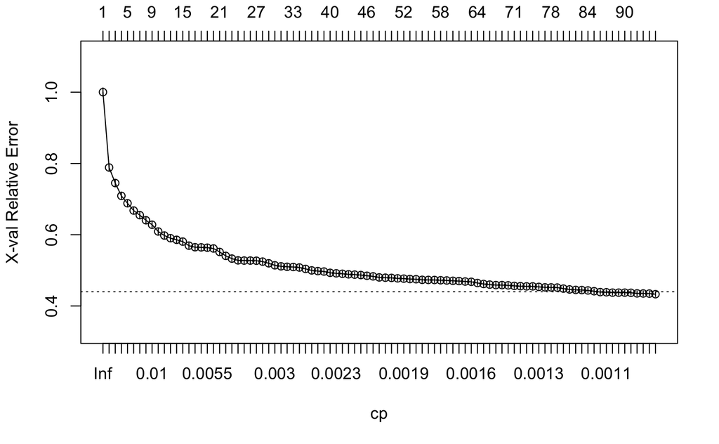

```r
train_tree<-cbind.data.frame(train.outcome,train.features.s)

tree_fit <- rpart(train.outcome ~ ., data = train_tree, control=rpart.control(cp=0.001))
#tree_fit  # describe the model

plotcp(tree_fit) # cp: complexity parameter, dimension of the tree
```

I look at the function to set the complexity of the model.

To visualize the regression tree:

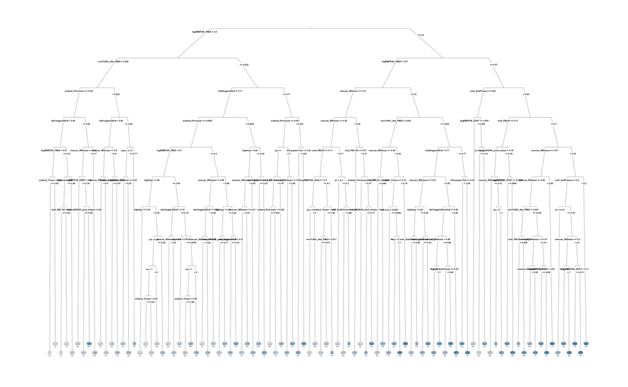

```r
#summary(tree_fit)
rpart.plot::rpart.plot(
  tree_fit,
  type = 3,
  branch = .75,
  under = TRUE
)
```

Variables importance:

```r
tree_fit$variable.importance
```

```
        logEMEPUK_PM25         logEMEPUK_PM10            era5_PBL12h          mescan_WDmean          mescan_WSmean
          1045.8059170            640.9409947            421.7769007            348.1934056            304.6742722
         eraland_Tmean   nonTraffic_dist_PM25       eraland_Precmean      Traffic_dist_PM25          mescan_RHmean
           290.6054731            282.7720409            229.8878324            220.0538396            215.3069100
       idw2logpm25traf         era5_SeaPrmean        idw1logpm25traf                highway              airp.invd
           211.8952173            196.0041306            191.0588920            155.7315138            142.1848315
    idw1logpm25nontraf        logEMEPUK_SSALT             era5_PBL0h         logEMEPUK_DUST                    cl1
           128.1392832            116.2817437            114.1693865            103.2630375             89.1805308
best_AOD055_pred_measu          OA.popwei.1km               sea.invd                  local              night.1km
            78.7743929             69.8074727             53.4599891             50.0769820             47.9925812
                    we                   ndvi               elev.1km                    Nov                    cl2
            31.4463252             28.5470598             26.5117467             25.5928719             20.8441554
                   Jan                    May                    cl6                    Mar                    Aug
            16.6367299             16.4113074             14.5192114              9.7973136              7.7837657
                  ImpS                    Feb                    cl5                    cl4                    Jul
             7.6257516              6.5413668              6.1655808              6.1325355              5.4154750
                   cl3                    Oct                    Jun                    Apr                    Sep
             4.5036172              3.9313105              2.6775971              1.7152107              0.8754477
```

Prediction on train set:

```r
pred_tree_train <- predict(tree_fit, train.features.s)

postResample(pred_tree_train, train.outcome)
```

```
     RMSE  Rsquared       MAE
0.2930890 0.6139352 0.2259482
```

Prediction on test set:

```r
pred_tree_test <- predict(tree_fit, test.features.s)

caret::postResample(pred_tree_test, test.outcome)
```

```
     RMSE  Rsquared       MAE
0.3255728 0.5426775 0.2492586
```

Performance is similar to the Multivariate Adaptive Regression Splines with interactions.

# RANDOM FOREST

Ensemble model whchi use bagging of regression trees build over subset of the initial dataset. Parameters: num.trees=500, so 500 trees, mtry=20 to limit to 20 possible random predictors

```r
formula.pm10 <- as.formula(paste("train.outcome", paste(names(train.features.s),collapse="+"), sep="~"))

trainrf<-cbind.data.frame(train.features.s, train.outcome)

modfull <- ranger(formula.pm10, data=trainrf, num.trees=500, mtry=20, # max predictors per tree
                  respect.unordered.factors=TRUE, importance="impurity",
                  seed=23)
```

Using importance=“impurity” command investigates key variables in prediction. Importance calculated as average SSE reduction when variable used compared to all trees. Absolute values:

```r
abs.impo<-modfull$variable.importance
(abs.impo<-abs.impo[order(abs.impo)])
```

```
                   cl7                    cl3                    Jul                    Sep                    Aug
              1.083570               2.566734               3.126461               3.510034               4.218870
                   Nov                    Jan                    Feb                    Jun                    cl2
              4.848144               5.223191               6.574538               7.221948               7.339836
                   cl5                    Apr                    Mar                    cl4                    cl6
              8.135930               8.332017               9.318566              12.961419              15.873347
                   May                   ImpS              secondary                    Oct               elev.1km
             16.289191              22.258932              22.471511              22.570713              25.910319
              sea.invd              airp.invd     idw1logpm25nontraf                     we              night.1km
             29.631878              34.112563              35.524305              36.528895              39.611358
                 local          OA.popwei.1km        idw1logpm25traf                   ndvi                    cl1
             42.773945              44.159911              52.503823              53.597176              61.723198
           era5_PBL12h                highway         logEMEPUK_DUST      Traffic_dist_PM25        logEMEPUK_SSALT
             78.126750              89.837914              94.322146              96.861240             102.122785
       idw2logpm25traf best_AOD055_pred_measu         era5_SeaPrmean          eraland_Tmean   nonTraffic_dist_PM25
            104.193290             118.542002             119.715977             130.937267             143.540335
            era5_PBL0h          mescan_WSmean       eraland_Precmean          mescan_RHmean         logEMEPUK_PM10
            158.835891             166.347737             200.218597             210.708679             323.434273
         mescan_WDmean         logEMEPUK_PM25
            334.830991             716.721782
```

Relative values:

```r
rel.impo<-(round(modfull$variable.importance/sum(modfull$variable.importance),3)*100)
(rel.impo<-rel.impo[order(rel.impo)])
```

```
                   cl7                    Jan                    Jul                    Aug                    Sep
                   0.0                    0.1                    0.1                    0.1                    0.1
                   Nov                    cl3                    Feb                    Mar                    Apr
                   0.1                    0.1                    0.2                    0.2                    0.2
                   Jun                    cl2                    cl5                    cl4                    May
                   0.2                    0.2                    0.2                    0.3                    0.4
                   cl6                    Oct              secondary                   ImpS               elev.1km
                   0.4                    0.6                    0.6                    0.6                    0.7
              sea.invd              airp.invd     idw1logpm25nontraf                     we              night.1km
                   0.8                    0.9                    0.9                    1.0                    1.0
                 local          OA.popwei.1km                   ndvi        idw1logpm25traf                    cl1
                   1.1                    1.2                    1.4                    1.4                    1.6
           era5_PBL12h                highway         logEMEPUK_DUST      Traffic_dist_PM25        logEMEPUK_SSALT
                   2.0                    2.3                    2.5                    2.5                    2.7
       idw2logpm25traf         era5_SeaPrmean best_AOD055_pred_measu          eraland_Tmean   nonTraffic_dist_PM25
                   2.7                    3.1                    3.1                    3.4                    3.7
            era5_PBL0h          mescan_WSmean       eraland_Precmean          mescan_RHmean         logEMEPUK_PM10
                   4.1                    4.3                    5.2                    5.5                    8.4
         mescan_WDmean         logEMEPUK_PM25
                   8.7                   18.7
```

```r
pred_forest_train<- predict(modfull, trainrf)$prediction

postResample(pred_forest_train, train.outcome)
```

```
      RMSE   Rsquared        MAE
0.08435997 0.97461323 0.06041904
```

```r
testrf<-cbind.data.frame(test.features.s,test.outcome)

pred_forest_test<- predict(modfull, testrf)$prediction

postResample(pred_forest_test, test.outcome)
```

```
     RMSE  Rsquared       MAE
0.1940303 0.8470826 0.1398756
```

The model’s predictive capacity increases to R^2 = 0.975 in the training dataset and R^2 = 0.847 in the validation dataset.

# Neural Networks

```r
train.outcome.s<-(train.outcome - min(train.outcome)) / (max(train.outcome) - min(train.outcome))

train.nn<-cbind.data.frame(train.outcome.s,train.features.s)
```

```r
namesnn <- names(train.nn)

form <- as.formula(paste("train.outcome.s ~", paste(namesnn[!namesnn %in% "train.outcome.s"], collapse = " + ")))
form
```

```
train.outcome.s ~ we + Jan + Feb + Mar + Apr + May + Jun + Jul +
    Aug + Sep + Oct + Nov + highway + secondary + local + sea.invd +
    airp.invd + OA.popwei.1km + night.1km + ImpS + elev.1km +
    ndvi + cl1 + cl2 + cl3 + cl4 + cl5 + cl6 + cl7 + era5_PBL0h +
    era5_PBL12h + era5_SeaPrmean + eraland_Tmean + eraland_Precmean +
    mescan_RHmean + mescan_WDmean + mescan_WSmean + best_AOD055_pred_measu +
    logEMEPUK_PM25 + logEMEPUK_PM10 + logEMEPUK_DUST + logEMEPUK_SSALT +
    Traffic_dist_PM25 + nonTraffic_dist_PM25 + idw2logpm25traf +
    idw1logpm25traf + idw1logpm25nontraf
```

Net with just one hidden layer of 32 nodes and linear activation function.

```r
nnfit <- neuralnet(form, data = train.nn, rep=1, stepmax=100000, lifesign="full", threshold=0.1, hidden=c(32), linear.output = TRUE)
```

[output not shown]

[output cut: 76 more lines]

```r
#nnfit <- neuralnet(form, data = train.nn, rep=1, stepmax=100000, lifesign="full", threshold=0.1, hidden=c(1), linear.output = FALSE,act.fct="logistic")
```

Model info:

```r
#nnfit$result.matrix
```

Nodes weights:

```r
weights<-nnfit$result.matrix[5:50,]

(weights<-weights[order(weights)])
```

```
                   cl3.to.1layhid1         era5_SeaPrmean.to.1layhid1         logEMEPUK_DUST.to.1layhid1
                       -5.03393276                        -4.97457857                        -3.20672377
                   Mar.to.1layhid1        idw1logpm25traf.to.1layhid1 best_AOD055_pred_measu.to.1layhid1
                       -2.86112076                        -2.83172000                        -2.81467799
            era5_PBL0h.to.1layhid1          mescan_WSmean.to.1layhid1        logEMEPUK_SSALT.to.1layhid1
                       -2.76251778                        -2.75484134                        -2.17054444
                   Feb.to.1layhid1                    cl2.to.1layhid1                    May.to.1layhid1
                       -1.27538414                        -1.10981510                        -1.01334180
                 local.to.1layhid1                    Jul.to.1layhid1         logEMEPUK_PM10.to.1layhid1
                       -0.67788902                        -0.65073806                        -0.57958951
                   cl1.to.1layhid1                   ndvi.to.1layhid1          mescan_WDmean.to.1layhid1
                       -0.46931976                        -0.39638584                        -0.34051561
             secondary.to.1layhid1   nonTraffic_dist_PM25.to.1layhid1          mescan_RHmean.to.1layhid1
                       -0.27828121                         0.06133555                         0.06595947
                    we.to.1layhid1          OA.popwei.1km.to.1layhid1              night.1km.to.1layhid1
                        0.07291123                         0.09997829                         0.15547018
     Traffic_dist_PM25.to.1layhid1                highway.to.1layhid1         logEMEPUK_PM25.to.1layhid1
                        0.18242460                         0.24835744                         0.41341495
             airp.invd.to.1layhid1                    cl4.to.1layhid1                    Jun.to.1layhid1
                        0.44176224                         0.44957992                         0.46827379
              elev.1km.to.1layhid1                   ImpS.to.1layhid1                    cl6.to.1layhid1
                        0.76672425                         1.04660304                         1.08691673
                   Apr.to.1layhid1                    Jan.to.1layhid1                    Nov.to.1layhid1
                        1.80686377                         2.38282246                         2.38904828
       idw2logpm25traf.to.1layhid1          eraland_Tmean.to.1layhid1                    cl7.to.1layhid1
                        2.45155189                         2.71368839                         4.69413831
           era5_PBL12h.to.1layhid1       eraland_Precmean.to.1layhid1               sea.invd.to.1layhid1
                        4.75724184                         4.76981051                         6.10450723
                   Aug.to.1layhid1                    Sep.to.1layhid1                    Oct.to.1layhid1
                       37.66469610                        39.49344029                        39.75104504
                   cl5.to.1layhid1
                       63.72893095
```

Show the Neural Network

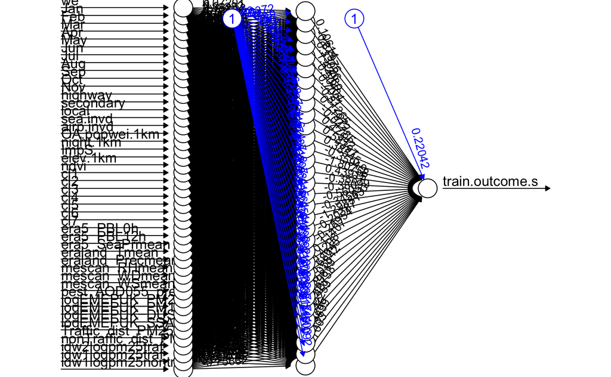

```r
plot(nnfit)
```

Prediction on train set

```r
pred_nn_train <- predict(nnfit,train.features.s)
postResample(pred_nn_train, train.outcome.s)
```

```
      RMSE   Rsquared        MAE
0.03424953 0.84974964 0.02624336
```

Predictions on test set

```r
test.outcome.s<-(test.outcome - min(test.outcome)) / (max(test.outcome) - min(test.outcome))

pred_nn_test <-predict(nnfit,newdata=test.features.s)
postResample(pred_nn_test, test.outcome.s)
```

```
      RMSE   Rsquared        MAE
0.08651663 0.44044081 0.06087688
```

With just one hidden layer the neural net performs well in training set, but only achieved R^2 = 0.44 on the test set.

# SVM Support Vector Regression

```r
library(e1071)
# SVR model
svr_model <- svm(x = train.features.s, y = train.outcome.s, kernel = "radial")
```

Prediction on train set

```r
pred_svr_train <- predict(svr_model,train.features.s)
postResample(pred_svr_train, train.outcome.s)
```

```
      RMSE   Rsquared        MAE
0.03209966 0.87122655 0.02239932
```

Predictions on test set

```r
pred_svr_test <-predict(svr_model,newdata=test.features.s)
postResample(pred_svr_test, test.outcome.s)
```

```
      RMSE   Rsquared        MAE
0.04535625 0.76972557 0.03361057
```

Unlike traditional linear regression, SVR allows for the identification of non-linear relationships by introducing a mapping into a higher-dimensional space through the use of kernel function. This can be seen by observing the good performance in prediction of SVR, considering R^2 = 87,12% on train and 76,97 % on test compared to the linear one.